# Earthquake data

```python
import numpy as np # linear algebra
import pandas as pd # dataframes
import matplotlib.pyplot as plt # General visualisations
import matplotlib.ticker as mtick # Axis visuals
import seaborn as sns # Statistical visualisations
from math import pi # Radar chart support
```

```python
df= pd.read_csv("csv_building_structure.csv")
```

```python
df.head()
```

|  | building_id | district_id | vdcmun_id | ward_id | count_floors_pre_eq | count_floors_post_eq | age_building | plinth_area_sq_ft | height_ft_pre_eq | height_ft_post_eq | ... | has_superstructure_mud_mortar_brick | has_superstructure_cement_mortar_brick | has_superstructure_timber | has_superstructure_bamboo | has_superstructure_rc_non_engineered | has_superstructure_rc_engineered | has_superstructure_other | condition_post_eq | damage_grade | technical_solution_proposed |
| --- | --- | --- | --- | --- | --- | --- | --- | --- | --- | --- | --- | --- | --- | --- | --- | --- | --- | --- | --- | --- | --- |
| 0 | 120101000011 | 12 | 1207 | 120703 | 1 | 1 | 9 | 288 | 9 | 9 | ... | 0 | 0 | 0 | 1 | 0 | 0 | 0 | Damaged-Used in risk | Grade 3 | Major repair |
| 1 | 120101000021 | 12 | 1207 | 120703 | 1 | 1 | 15 | 364 | 9 | 9 | ... | 0 | 0 | 0 | 1 | 0 | 0 | 0 | Damaged-Repaired and used | Grade 5 | Reconstruction |
| 2 | 120101000031 | 12 | 1207 | 120703 | 1 | 1 | 20 | 384 | 9 | 9 | ... | 0 | 0 | 0 | 0 | 0 | 0 | 0 | Damaged-Repaired and used | Grade 2 | Minor repair |
| 3 | 120101000041 | 12 | 1207 | 120703 | 1 | 1 | 20 | 312 | 9 | 9 | ... | 0 | 0 | 0 | 0 | 0 | 0 | 0 | Damaged-Repaired and used | Grade 2 | Minor repair |
| 4 | 120101000051 | 12 | 1207 | 120703 | 1 | 1 | 30 | 308 | 9 | 9 | ... | 0 | 0 | 0 | 0 | 0 | 0 | 0 | Damaged-Repaired and used | Grade 1 | Minor repair |

5 rows × 31 columns

```python
df.info()
```

```
<class 'pandas.core.frame.DataFrame'>
RangeIndex: 762106 entries, 0 to 762105
Data columns (total 31 columns):
 #   Column                                  Non-Null Count   Dtype
---  ------                                  --------------   -----
 0   building_id                             762106 non-null  int64
 1   district_id                             762106 non-null  int64
 2   vdcmun_id                               762106 non-null  int64
 3   ward_id                                 762106 non-null  int64
 4   count_floors_pre_eq                     762106 non-null  int64
 5   count_floors_post_eq                    762106 non-null  int64
 6   age_building                            762106 non-null  int64
 7   plinth_area_sq_ft                       762106 non-null  int64
 8   height_ft_pre_eq                        762106 non-null  int64
 9   height_ft_post_eq                       762106 non-null  int64
```

[output cut: 23 more lines]

```python
display(df.dtypes.value_counts())
```

```
int64     21
object    10
dtype: int64
```

```python
##displaying the count of the null values of the features
df_temp=df.isnull().sum().reset_index(name='count')
display(df_temp[df_temp['count']>0])
```

|  | index | count |
| --- | --- | --- |
| 15 | position | 1 |
| 16 | plan_configuration | 1 |
| 29 | damage_grade | 12 |
| 30 | technical_solution_proposed | 12 |

```python
##dropping the rows of the missing values
df.dropna(inplace=True)
```

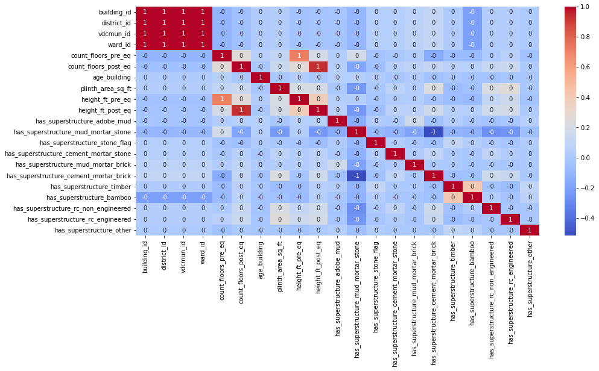

```python
plt.figure(figsize=(15,7))
df_corr=sns.heatmap(df.corr(), cmap='coolwarm', annot=True, fmt=',.0f')
plt.show()
```

# Expolatory Data analysis

```python
df_grade=df['damage_grade'].value_counts()
print(df_grade)
```

```
Grade 5    275766
Grade 4    183844
Grade 3    136412
Grade 2     87257
Grade 1     78815
Name: damage_grade, dtype: int64
```

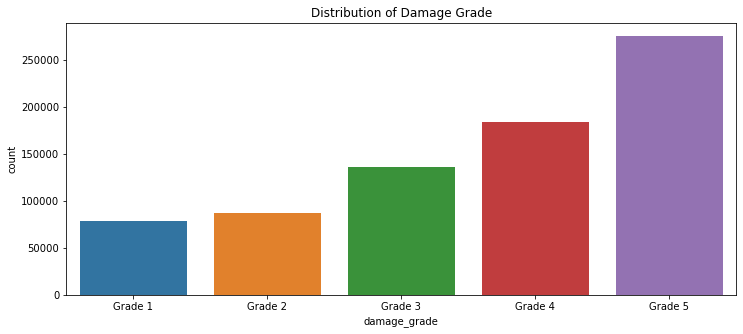

```python
plt.figure(figsize=(12,5))
grade=sns.countplot(x='damage_grade', data=df, order=['Grade 1','Grade 2','Grade 3','Grade 4','Grade 5'])
plt.title("Distribution of Damage Grade")
```

```python
##checking the features with categorical datatypes.
df.select_dtypes(include='object').dtypes
```

```
land_surface_condition         object
foundation_type                object
roof_type                      object
ground_floor_type              object
other_floor_type               object
position                       object
plan_configuration             object
condition_post_eq              object
damage_grade                   object
technical_solution_proposed    object
dtype: object
```

```python
df_temp = df.groupby(['district_id','damage_grade']).size().reset_index(name='count')
```

```python
df_temp = df_temp.set_index(['district_id', 'damage_grade'])
```

```python
df_temp.head(10)
```

| district_id | damage_grade | count |
| --- | --- | --- |
| 12 | Grade 1 | 7961 |
|  | Grade 2 | 8605 |
|  | Grade 3 | 9220 |
|  | Grade 4 | 7946 |
|  | Grade 5 | 5620 |
| 20 | Grade 1 | 13087 |
|  | Grade 2 | 14469 |
|  | Grade 3 | 17085 |
|  | Grade 4 | 15917 |
|  | Grade 5 | 8191 |

```python
df_temp = pd.pivot_table(df_temp, values='count', index=['district_id'], columns='damage_grade')
```

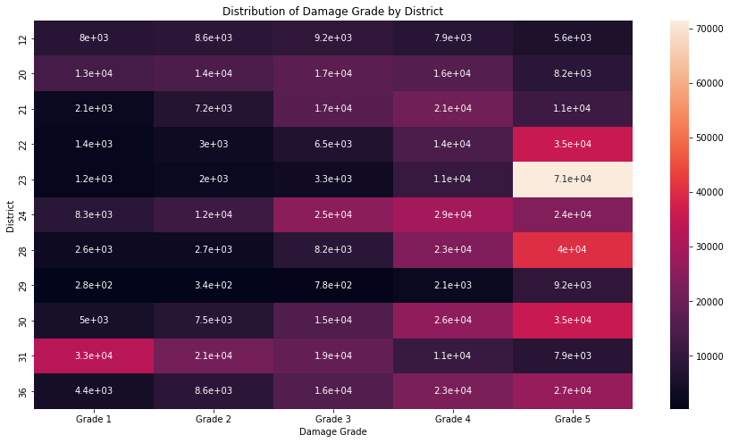

```python
# Plot char
plt.figure(figsize=(15,8))
ax = sns.heatmap(data = df_temp, annot = True )
plt.title("Distribution of Damage Grade by District")
plt.xlabel("Damage Grade")
plt.ylabel("District")
plt.show()
##del df_temp, ax
```

```python
print("VDCmun ids: {}" .format(len(df['vdcmun_id'].unique())))
print("WARD ids: {}" .format(len(df['ward_id'].unique())))
```

```
VDCmun ids: 110
WARD ids: 945
```

The output above shows that there are 110 vdcmun and 945 unique ward_id's in the dataset. It might be prudent to do some dimensionality reduction when it comes to model building.

```python
df['land_surface_condition'].value_counts()
```

```
Flat              631663
Moderate slope    105640
Steep slope        24791
Name: land_surface_condition, dtype: int64
```

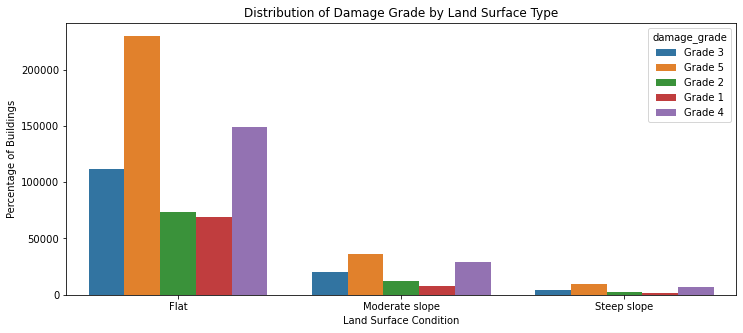

```python
plt.figure(figsize=(12,5))
sns.countplot(x='land_surface_condition', data=df, hue='damage_grade')
plt.title("Distribution of Damage Grade by Land Surface Type")
plt.xlabel("Land Surface Condition")
plt.ylabel("Percentage of Buildings")
plt.show()
```

The following above graph shows that the Flat land surface condition has the highest count comparetively to Moderate Slope and steep slope.

```python
##To check the counts of the Foundation type feature.
df.foundation_type.value_counts()
```

```
Mud mortar-Stone/Brick    628705
Bamboo/Timber              57472
Cement-Stone/Brick         39245
RC                         32120
Other                       4552
Name: foundation_type, dtype: int64
```

```python
##Groupby the two features adding another column of Counting the values.

df_temp = df.groupby(['foundation_type','damage_grade']).size().reset_index(name='count')
```

```python
##setting foundation_type and damage_grade into index form
df_temp = df_temp.set_index(['foundation_type', 'damage_grade'])
```

```python
df_temp
```

| foundation_type | damage_grade | count |
| --- | --- | --- |
| Bamboo/Timber | Grade 1 | 17201 |
|  | Grade 2 | 13357 |
|  | Grade 3 | 13244 |
|  | Grade 4 | 8368 |
|  | Grade 5 | 5302 |
| Cement-Stone/Brick | Grade 1 | 11642 |
|  | Grade 2 | 8847 |
|  | Grade 3 | 7104 |
|  | Grade 4 | 5621 |
|  | Grade 5 | 6031 |
| Mud mortar-Stone/Brick | Grade 1 | 29484 |
|  | Grade 2 | 56044 |
|  | Grade 3 | 112442 |
|  | Grade 4 | 168458 |
|  | Grade 5 | 262277 |
| Other | Grade 1 | 1364 |
|  | Grade 2 | 405 |
|  | Grade 3 | 459 |
|  | Grade 4 | 691 |
|  | Grade 5 | 1633 |
| RC | Grade 1 | 19124 |
|  | Grade 2 | 8604 |
|  | Grade 3 | 3163 |
|  | Grade 4 | 706 |
|  | Grade 5 | 523 |

```python
##changing the count numbers into percentage
df_temp = df_temp.groupby(level=0).apply(lambda x: 100 * x / float(x.sum())).reset_index()
```

```python
df_temp
```

|  | foundation_type | damage_grade | count |
| --- | --- | --- | --- |
| 0 | Bamboo/Timber | Grade 1 | 29.929357 |
| 1 | Bamboo/Timber | Grade 2 | 23.240883 |
| 2 | Bamboo/Timber | Grade 3 | 23.044265 |
| 3 | Bamboo/Timber | Grade 4 | 14.560134 |
| 4 | Bamboo/Timber | Grade 5 | 9.225362 |
| 5 | Cement-Stone/Brick | Grade 1 | 29.664925 |
| 6 | Cement-Stone/Brick | Grade 2 | 22.542999 |
| 7 | Cement-Stone/Brick | Grade 3 | 18.101669 |
| 8 | Cement-Stone/Brick | Grade 4 | 14.322844 |
| 9 | Cement-Stone/Brick | Grade 5 | 15.367563 |
| 10 | Mud mortar-Stone/Brick | Grade 1 | 4.689640 |
| 11 | Mud mortar-Stone/Brick | Grade 2 | 8.914197 |
| 12 | Mud mortar-Stone/Brick | Grade 3 | 17.884700 |
| 13 | Mud mortar-Stone/Brick | Grade 4 | 26.794443 |
| 14 | Mud mortar-Stone/Brick | Grade 5 | 41.717021 |
| 15 | Other | Grade 1 | 29.964851 |
| 16 | Other | Grade 2 | 8.897188 |
| 17 | Other | Grade 3 | 10.083480 |
| 18 | Other | Grade 4 | 15.180141 |
| 19 | Other | Grade 5 | 35.874341 |
| 20 | RC | Grade 1 | 59.539228 |
| 21 | RC | Grade 2 | 26.787049 |
| 22 | RC | Grade 3 | 9.847447 |
| 23 | RC | Grade 4 | 2.198007 |
| 24 | RC | Grade 5 | 1.628269 |

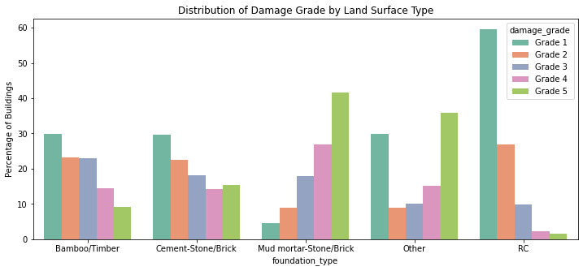

```python
plt.figure(figsize=(12,5))
sns.barplot(x='foundation_type',y='count', data=df_temp, hue='damage_grade',palette="Set2")
plt.title("Distribution of Damage Grade by Land Surface Type")
plt.xlabel("foundation_type")
plt.ylabel("Percentage of Buildings")
plt.show()
```

```python
df.roof_type.value_counts()
```

```
Bamboo/Timber-Light roof    503736
Bamboo/Timber-Heavy roof    213774
RCC/RB/RBC                   44584
Name: roof_type, dtype: int64
```

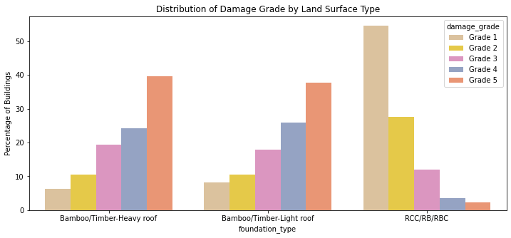

```python
df_roof = df.groupby(['roof_type','damage_grade']).size().reset_index(name='count')
df_roof = df_roof.set_index(['roof_type', 'damage_grade'])
df_roof = df_roof.groupby(level=0).apply(lambda x: 100 * x / float(x.sum())).reset_index()


plt.figure(figsize=(12,5))
sns.barplot(x='roof_type',y='count', data=df_roof, hue='damage_grade',palette="Set2_r")
plt.title("Distribution of Damage Grade by Land Surface Type")
plt.xlabel("foundation_type")
plt.ylabel("Percentage of Buildings")
plt.show()
```

The spread of building between roof type and grade is quite similar for the types with Bamboo and timber. Roof type RCC actually is most commonly associated with grade 1 and then 2, it is minimally associated with grades 4 and 5. Given the similarities between the two bamboo/ timber roof types, they could potentially be grouped together.

```python
df_roof = df_roof.set_index(['roof_type', 'damage_grade'])
```

```python
df_roof = pd.pivot_table(df_roof, values='count', index=['roof_type'], columns='damage_grade')

df_roof
```

| damage_grade roof_type | Grade 1 | Grade 2 | Grade 3 | Grade 4 | Grade 5 |
| --- | --- | --- | --- | --- | --- |
| Bamboo/Timber-Heavy roof | 6.314145 | 10.475549 | 19.304031 | 24.211083 | 39.695192 |
| Bamboo/Timber-Light roof | 8.137000 | 10.432449 | 17.830967 | 25.909008 | 37.690576 |
| RCC/RB/RBC | 54.566661 | 27.613045 | 11.941504 | 3.530414 | 2.348376 |

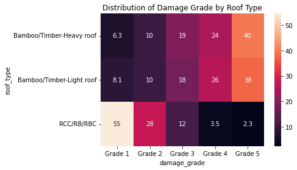

```python
acorr = sns.heatmap(data = df_roof, annot = True )
plt.title("Distribution of Damage Grade by Roof Type")
plt.show()
```

```python
df.ground_floor_type.value_counts()
```

```
Mud            618205
RC              73149
Brick/Stone     66093
Timber           3594
Other            1053
Name: ground_floor_type, dtype: int64
```

```python
df_ground = df.groupby(['ground_floor_type','damage_grade']).size().reset_index(name='count')
df_ground = df_ground.set_index(['ground_floor_type', 'damage_grade'])
df_ground = df_ground.groupby(level=0).apply(lambda x: 100 * x / float(x.sum())).reset_index()
df_ground = pd.pivot_table(df_ground, values='count', index=['ground_floor_type'], columns='damage_grade')

df_ground
```

| damage_grade ground_floor_type | Grade 1 | Grade 2 | Grade 3 | Grade 4 | Grade 5 |
| --- | --- | --- | --- | --- | --- |
| Brick/Stone | 8.935893 | 10.169004 | 16.390541 | 25.104020 | 39.400542 |
| Mud | 6.158637 | 9.622536 | 18.440647 | 26.118521 | 39.659660 |
| Other | 27.635328 | 18.993352 | 22.697056 | 16.714150 | 13.960114 |
| RC | 46.291815 | 27.577957 | 14.782157 | 6.649442 | 4.698629 |
| Timber | 19.003895 | 18.809126 | 14.635504 | 20.756817 | 26.794658 |

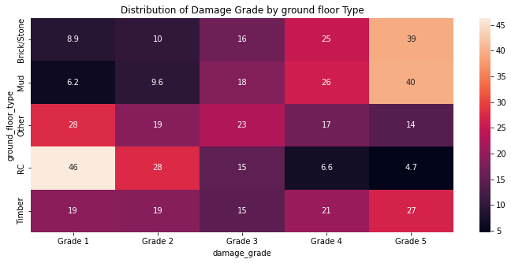

```python
plt.figure(figsize=(12,5))
acorr = sns.heatmap(data = df_ground, annot = True )
plt.title("Distribution of Damage Grade by ground floor Type")
plt.show()
```

There are multiple types of ground floor material used across the buildings, one the most popular is Mud which can be seen below. RC and Brick are distant second/ third place but occur quite frequently. Interestingly the association between ground type and damage grade differs quite significantly dependent on materials used for the ground. Materials Other and Timber are spread quite evenly across the grades, while brick/ stone and mud are more often associated with the higher grades 4 and 5, RC is most commonly associated with the lower grades. These patterns indicate that this variable might have some predictive power.

```python
df.columns
```

```
Index(['building_id', 'district_id', 'vdcmun_id', 'ward_id',
       'count_floors_pre_eq', 'count_floors_post_eq', 'age_building',
       'plinth_area_sq_ft', 'height_ft_pre_eq', 'height_ft_post_eq',
       'land_surface_condition', 'foundation_type', 'roof_type',
       'ground_floor_type', 'other_floor_type', 'position',
       'plan_configuration', 'has_superstructure_adobe_mud',
       'has_superstructure_mud_mortar_stone', 'has_superstructure_stone_flag',
       'has_superstructure_cement_mortar_stone',
       'has_superstructure_mud_mortar_brick',
       'has_superstructure_cement_mortar_brick', 'has_superstructure_timber',
       'has_superstructure_bamboo', 'has_superstructure_rc_non_engineered',
       'has_superstructure_rc_engineered', 'has_superstructure_other',
       'condition_post_eq', 'damage_grade', 'technical_solution_proposed'],
      dtype='object')
```

```python
df.position.value_counts()
```

```
Not attached       604443
Attached-1 side    129431
Attached-2 side     26910
Attached-3 side      1310
Name: position, dtype: int64
```

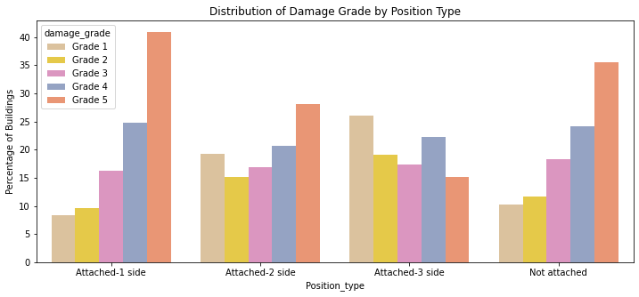

```python
df_position = df.groupby(['position','damage_grade']).size().reset_index(name='count')
df_position = df_position.set_index(['position', 'damage_grade'])
df_position = df_position.groupby(level=0).apply(lambda x: 100 * x / float(x.sum())).reset_index()

plt.figure(figsize=(12,5))
sns.barplot(x='position',y='count', data=df_position, hue='damage_grade',palette="Set2_r")
plt.title("Distribution of Damage Grade by Position Type")
plt.xlabel("Position_type")
plt.ylabel("Percentage of Buildings")
plt.show()
```

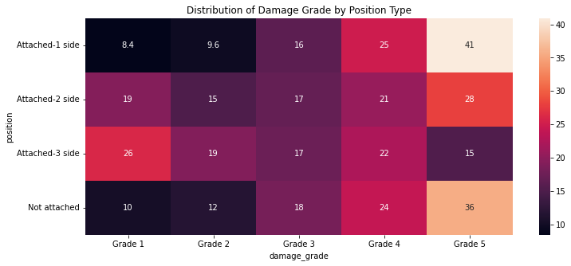

```python
df_position = pd.pivot_table(df_position, values='count', index=['position'], columns='damage_grade')



plt.figure(figsize=(12,5))
acorr = sns.heatmap(data = df_position, annot = True )
plt.title("Distribution of Damage Grade by Position Type")
plt.show()
```

```python
df_position
```

| damage_grade position | Grade 1 | Grade 2 | Grade 3 | Grade 4 | Grade 5 |
| --- | --- | --- | --- | --- | --- |
| Attached-1 side | 8.429974 | 9.634477 | 16.178504 | 24.861123 | 40.895921 |
| Attached-2 side | 19.253066 | 15.120773 | 16.874768 | 20.702341 | 28.049052 |
| Attached-3 side | 26.030534 | 19.160305 | 17.328244 | 22.290076 | 15.190840 |
| Not attached | 10.320576 | 11.658171 | 18.315044 | 24.121877 | 35.584331 |

```python
df.plan_configuration.value_counts()
```

```
Rectangular                        731246
Square                              17576
L-shape                             10079
T-shape                               969
Multi-projected                       940
Others                                518
U-shape                               448
E-shape                               140
Building with Central Courtyard        98
H-shape                                80
Name: plan_configuration, dtype: int64
```

```python
 df.condition_post_eq.value_counts()
```

```
Damaged-Not used                           207968
Damaged-Rubble unclear                     125650
Damaged-Used in risk                       123843
Damaged-Repaired and used                  107791
Damaged-Rubble clear                       102191
Not damaged                                 61139
Damaged-Rubble Clear-New building built     33130
Covered by landslide                          382
Name: condition_post_eq, dtype: int64
```

```python
df.technical_solution_proposed.value_counts()
```

```
Reconstruction    470219
Major repair      129415
Minor repair      110605
No need            51855
Name: technical_solution_proposed, dtype: int64
```

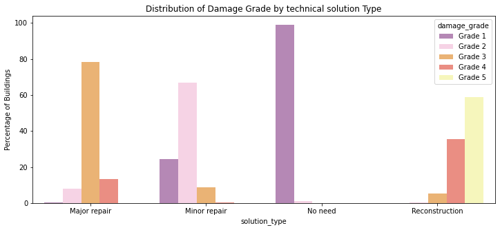

```python
df_solution = df.groupby(['technical_solution_proposed','damage_grade']).size().reset_index(name='count')
df_solution = df_solution.set_index(['technical_solution_proposed', 'damage_grade'])
df_solution = df_solution.groupby(level=0).apply(lambda x: 100 * x / float(x.sum())).reset_index()

plt.figure(figsize=(12,5))
sns.barplot(x='technical_solution_proposed',y='count', data=df_solution, hue='damage_grade',palette="Set3_r")
plt.title("Distribution of Damage Grade by technical solution Type")
plt.xlabel("solution_type")
plt.ylabel("Percentage of Buildings")
plt.show()
```

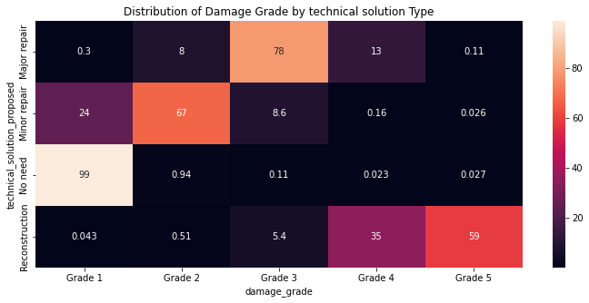

```python
df_solution = pd.pivot_table(df_solution, values='count', index=['technical_solution_proposed'], columns='damage_grade')



plt.figure(figsize=(12,5))
acorr = sns.heatmap(data = df_solution, annot = True )
plt.title("Distribution of Damage Grade by technical solution Type")
plt.show()
```

The final categorical variable identifies the scale of damage caused to the building into 4 groups going from no need to intervention to complete reconstruction. The majority of buildings required reconstruction or some degree of repair. The plot shows a nice pattern, ultimately Grade 1 buildings not requiring any intervention, grades 2 and 3 requiring minor and major repair respectively and then grades 4 and 5 requiring reconstruction.

```python
# Describe the
df.describe().transpose().drop('count', axis=1)
```

|  | mean | std | min | 25% | 50% | 75% | max |
| --- | --- | --- | --- | --- | --- | --- | --- |
| building_id | 2.607522e+11 | 5.801868e+10 | 1.201010e+11 | 2.219090e+11 | 2.463020e+11 | 3.036080e+11 | 3.667090e+11 |
| district_id | 2.576791e+01 | 5.807569e+00 | 1.200000e+01 | 2.200000e+01 | 2.400000e+01 | 3.000000e+01 | 3.600000e+01 |
| vdcmun_id | 2.582696e+03 | 5.811742e+02 | 1.201000e+03 | 2.204000e+03 | 2.410000e+03 | 3.010000e+03 | 3.611000e+03 |
| ward_id | 2.582750e+05 | 5.811749e+04 | 1.201010e+05 | 2.204020e+05 | 2.410040e+05 | 3.010060e+05 | 3.611080e+05 |
| count_floors_pre_eq | 2.087787e+00 | 6.551041e-01 | 1.000000e+00 | 2.000000e+00 | 2.000000e+00 | 2.000000e+00 | 9.000000e+00 |
| count_floors_post_eq | 1.252050e+00 | 1.063278e+00 | 0.000000e+00 | 0.000000e+00 | 1.000000e+00 | 2.000000e+00 | 9.000000e+00 |
| age_building | 2.432503e+01 | 6.503455e+01 | 0.000000e+00 | 9.000000e+00 | 1.600000e+01 | 2.700000e+01 | 9.990000e+02 |
| plinth_area_sq_ft | 4.066737e+02 | 2.267804e+02 | 7.000000e+01 | 2.800000e+02 | 3.580000e+02 | 4.700000e+02 | 5.000000e+03 |
| height_ft_pre_eq | 1.604942e+01 | 5.493900e+00 | 6.000000e+00 | 1.200000e+01 | 1.600000e+01 | 1.800000e+01 | 9.900000e+01 |
| height_ft_post_eq | 9.868785e+00 | 8.574218e+00 | 0.000000e+00 | 0.000000e+00 | 1.100000e+01 | 1.600000e+01 | 9.900000e+01 |
| has_superstructure_adobe_mud | 4.240159e-02 | 2.015037e-01 | 0.000000e+00 | 0.000000e+00 | 0.000000e+00 | 0.000000e+00 | 1.000000e+00 |
| has_superstructure_mud_mortar_stone | 8.002687e-01 | 3.997986e-01 | 0.000000e+00 | 1.000000e+00 | 1.000000e+00 | 1.000000e+00 | 1.000000e+00 |
| has_superstructure_stone_flag | 3.512165e-02 | 1.840874e-01 | 0.000000e+00 | 0.000000e+00 | 0.000000e+00 | 0.000000e+00 | 1.000000e+00 |
| has_superstructure_cement_mortar_stone | 1.581563e-02 | 1.247619e-01 | 0.000000e+00 | 0.000000e+00 | 0.000000e+00 | 0.000000e+00 | 1.000000e+00 |
| has_superstructure_mud_mortar_brick | 2.296173e-02 | 1.497816e-01 | 0.000000e+00 | 0.000000e+00 | 0.000000e+00 | 0.000000e+00 | 1.000000e+00 |
| has_superstructure_cement_mortar_brick | 7.152661e-02 | 2.577026e-01 | 0.000000e+00 | 0.000000e+00 | 0.000000e+00 | 0.000000e+00 | 1.000000e+00 |
| has_superstructure_timber | 2.587699e-01 | 4.379592e-01 | 0.000000e+00 | 0.000000e+00 | 0.000000e+00 | 1.000000e+00 | 1.000000e+00 |
| has_superstructure_bamboo | 8.048351e-02 | 2.720405e-01 | 0.000000e+00 | 0.000000e+00 | 0.000000e+00 | 0.000000e+00 | 1.000000e+00 |
| has_superstructure_rc_non_engineered | 3.979430e-02 | 1.954757e-01 | 0.000000e+00 | 0.000000e+00 | 0.000000e+00 | 0.000000e+00 | 1.000000e+00 |
| has_superstructure_rc_engineered | 1.638643e-02 | 1.269564e-01 | 0.000000e+00 | 0.000000e+00 | 0.000000e+00 | 0.000000e+00 | 1.000000e+00 |
| has_superstructure_other | 1.202608e-02 | 1.090021e-01 | 0.000000e+00 | 0.000000e+00 | 0.000000e+00 | 0.000000e+00 | 1.000000e+00 |

```python
df.drop(columns=['has_superstructure_adobe_mud',
       'has_superstructure_mud_mortar_stone', 'has_superstructure_stone_flag',
       'has_superstructure_cement_mortar_stone',
       'has_superstructure_mud_mortar_brick',
       'has_superstructure_cement_mortar_brick', 'has_superstructure_timber',
       'has_superstructure_bamboo', 'has_superstructure_rc_non_engineered',
       'has_superstructure_rc_engineered', 'has_superstructure_other'], inplace=True)
```

The output above shows the descriptive statistics about the numerical variables in our dataset. First thing to notice is that all the variables which have the 'has' prefix are binary variables. For the variables which aren't binary we can see that the mean and median values of the columns tend to be in a reasonable range indicating an absense of extreme values. Building age has a 8 year gap between the mean and median and we can see from the maximum value that the age is recorded as 999 years old. This is possible but potentially an outlier which might need to be addressed in later sections.

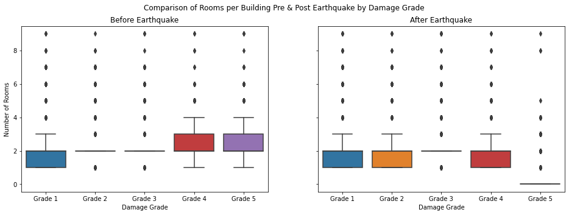

```python
fig, ax = plt.subplots(1,2,figsize = (16,5), sharey='row')
fig.suptitle("Comparison of Rooms per Building Pre & Post Earthquake by Damage Grade")
ax[0].set_title("Before Earthquake")
ax[1].set_title("After Earthquake")
sns.boxplot(data = df,
            x = "damage_grade",
            y = "count_floors_pre_eq",
            order = ['Grade 1', 'Grade 2', 'Grade 3', 'Grade 4', 'Grade 5'],
            ax = ax[0])
sns.boxplot(data = df,
            x = "damage_grade",
            y = "count_floors_post_eq",
            order = ['Grade 1', 'Grade 2', 'Grade 3', 'Grade 4', 'Grade 5'],
            ax = ax[1])
plt.setp(ax[:], xlabel='Damage Grade')
plt.setp(ax[0], ylabel='Number of Rooms')
plt.setp(ax[1], ylabel=None)
plt.show()
```

The plot above looks at the number of rooms a building had before and after the earthquake.

Focusing on the left plot (before earthquake) it shows the distribution of rooms that building had. Across all grades the vast majority of buildings had between 1 and 4 rooms, there are however a number of outliers per grade in which there were as many as 9 rooms across all grades. We can see a bit of a pattern emerging, moving from grades 1 - 5, the core distribution of rooms appears to grow. Essentially building with more rooms pre earthquake tend to have a worse outcome assessment. This might be based on area, in proximity to the earthquakes epicentre or another reason entirely.

Focussing on the right plot(after earthquake) we can see a pattern that higher damage grades equate to lower distribution of rooms than before. Lower damage grades tend to have a very similar distribution. In the following sections, a new feature could be interesting in which we extract the difference between these two variables.

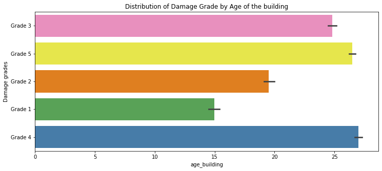

```python
plt.figure(figsize=(12,5))
sns.barplot(x='age_building',y='damage_grade' ,data=df,palette="Set1_r")
plt.title("Distribution of Damage Grade by Age of the building")
plt.xlabel("age_building")
plt.ylabel("Damage grades")
plt.show()
```

```python
df.shape
```

```
(762094, 20)
```

```python
df[(df.age_building >= 100)]
```

|  | building_id | district_id | vdcmun_id | ward_id | count_floors_pre_eq | count_floors_post_eq | age_building | plinth_area_sq_ft | height_ft_pre_eq | height_ft_post_eq | land_surface_condition | foundation_type | roof_type | ground_floor_type | other_floor_type | position | plan_configuration | condition_post_eq | damage_grade | technical_solution_proposed |
| --- | --- | --- | --- | --- | --- | --- | --- | --- | --- | --- | --- | --- | --- | --- | --- | --- | --- | --- | --- | --- |
| 470 | 120106000281 | 12 | 1207 | 120703 | 2 | 2 | 105 | 322 | 12 | 12 | Flat | Mud mortar-Stone/Brick | Bamboo/Timber-Light roof | Mud | TImber/Bamboo-Mud | Not attached | Rectangular | Damaged-Used in risk | Grade 3 | Major repair |
| 585 | 120107000641 | 12 | 1207 | 120703 | 1 | 1 | 100 | 298 | 9 | 9 | Flat | Mud mortar-Stone/Brick | Bamboo/Timber-Light roof | Mud | Not applicable | Not attached | Rectangular | Damaged-Repaired and used | Grade 3 | Major repair |
| 600 | 120107000791 | 12 | 1207 | 120703 | 1 | 1 | 100 | 322 | 9 | 9 | Flat | Mud mortar-Stone/Brick | Bamboo/Timber-Light roof | Mud | Not applicable | Not attached | Rectangular | Damaged-Repaired and used | Grade 1 | Minor repair |
| 1886 | 120304000801 | 12 | 1208 | 120802 | 1 | 1 | 187 | 155 | 11 | 11 | Steep slope | Mud mortar-Stone/Brick | Bamboo/Timber-Light roof | Mud | Not applicable | Not attached | Rectangular | Damaged-Repaired and used | Grade 3 | Major repair |
| 2004 | 120306000071 | 12 | 1208 | 120802 | 2 | 2 | 999 | 225 | 25 | 25 | Flat | Bamboo/Timber | Bamboo/Timber-Light roof | Mud | TImber/Bamboo-Mud | Not attached | Rectangular | Damaged-Used in risk | Grade 2 | Minor repair |
| ... | ... | ... | ... | ... | ... | ... | ... | ... | ... | ... | ... | ... | ... | ... | ... | ... | ... | ... | ... | ... |
| 761418 | 366705000261 | 36 | 3603 | 360301 | 2 | 0 | 100 | 415 | 12 | 0 | Flat | Mud mortar-Stone/Brick | Bamboo/Timber-Heavy roof | Mud | Timber-Planck | Not attached | Rectangular | Damaged-Rubble unclear | Grade 5 | Reconstruction |
| 761886 | 366708001031 | 36 | 3603 | 360302 | 2 | 0 | 100 | 450 | 16 | 0 | Flat | Mud mortar-Stone/Brick | Bamboo/Timber-Heavy roof | Mud | Timber-Planck | Not attached | Rectangular | Damaged-Rubble Clear-New building built | Grade 5 | Reconstruction |
| 761897 | 366708001141 | 36 | 3603 | 360302 | 2 | 0 | 100 | 437 | 18 | 0 | Flat | Mud mortar-Stone/Brick | Bamboo/Timber-Light roof | Mud | TImber/Bamboo-Mud | Not attached | Rectangular | Damaged-Rubble Clear-New building built | Grade 5 | Reconstruction |
| 761930 | 366708001451 | 36 | 3603 | 360302 | 2 | 0 | 100 | 528 | 18 | 0 | Flat | Mud mortar-Stone/Brick | Bamboo/Timber-Heavy roof | Mud | Timber-Planck | Not attached | Rectangular | Damaged-Rubble Clear-New building built | Grade 5 | Reconstruction |
| 762040 | 366709000651 | 36 | 3603 | 360302 | 2 | 0 | 100 | 420 | 18 | 0 | Flat | Mud mortar-Stone/Brick | Bamboo/Timber-Light roof | Mud | Timber-Planck | Attached-1 side | Rectangular | Damaged-Rubble Clear-New building built | Grade 5 | Reconstruction |

6404 rows × 20 columns

```python
df.drop(df[df['age_building'] >= 100].index, inplace = True)
print(df)
```

```
         building_id  district_id  vdcmun_id  ward_id  count_floors_pre_eq  \
0       120101000011           12       1207   120703                    1
1       120101000021           12       1207   120703                    1
2       120101000031           12       1207   120703                    1
3       120101000041           12       1207   120703                    1
4       120101000051           12       1207   120703                    1
...              ...          ...        ...      ...                  ...
762101  366709001241           36       3603   360302                    2
762102  366709001251           36       3603   360302                    2
762103  366709001261           36       3603   360302                    2
762104  366709001271           36       3603   360302                    2
762105  366709001281           36       3603   360302                    2

        count_floors_post_eq  age_building  plinth_area_sq_ft  \
0                          1             9                288
```

[output cut: 64 more lines]

```python
df.shape
```

```
(755690, 20)
```

```python
 df_age = df[(df.damage_grade == grade) & (df.age_building <= 100)] # filter
```

```python
df_age
```

|  | building_id | district_id | vdcmun_id | ward_id | count_floors_pre_eq | count_floors_post_eq | age_building | plinth_area_sq_ft | height_ft_pre_eq | height_ft_post_eq | land_surface_condition | foundation_type | roof_type | ground_floor_type | other_floor_type | position | plan_configuration | condition_post_eq | damage_grade | technical_solution_proposed |
| --- | --- | --- | --- | --- | --- | --- | --- | --- | --- | --- | --- | --- | --- | --- | --- | --- | --- | --- | --- | --- |

```python
 df_temp = df[df.damage_grade == grade]
```

```python
df_temp
```

|  | building_id | district_id | vdcmun_id | ward_id | count_floors_pre_eq | count_floors_post_eq | age_building | plinth_area_sq_ft | height_ft_pre_eq | height_ft_post_eq | land_surface_condition | foundation_type | roof_type | ground_floor_type | other_floor_type | position | plan_configuration | condition_post_eq | damage_grade | technical_solution_proposed |
| --- | --- | --- | --- | --- | --- | --- | --- | --- | --- | --- | --- | --- | --- | --- | --- | --- | --- | --- | --- | --- |

```python
df['net_rooms'] = df.count_floors_post_eq - df.count_floors_pre_eq
df['net_height'] = df.height_ft_post_eq - df.height_ft_pre_eq
```

```python
from sklearn.model_selection import train_test_split, cross_val_score, KFold
from sklearn.preprocessing import OneHotEncoder, StandardScaler, MinMaxScaler, FunctionTransformer, LabelEncoder, RobustScaler
from sklearn.feature_selection import VarianceThreshold
from sklearn.pipeline import Pipeline
from sklearn.compose import ColumnTransformer
from sklearn.neighbors import KNeighborsClassifier
from sklearn.ensemble import RandomForestClassifier, GradientBoostingClassifier
from sklearn.metrics import roc_auc_score, f1_score, confusion_matrix
```

```python
# Create training and testing data
x_train, x_test, y_train, y_test = train_test_split(df.drop('damage_grade', axis = 1),
                                                    df['damage_grade'],
                                                    test_size = 0.2,
                                                    random_state = 1989,
                                                    stratify = df['damage_grade'],
                                                    shuffle=True)


# Visualise proportions on train and test
pd.merge(y_train.reset_index(name="damage_grade").damage_grade.value_counts(normalize = True).reset_index(name="train"),
         y_test.reset_index(name="damage_grade").damage_grade.value_counts(normalize = True).reset_index(name="test"),
         on = "index",
         how = "left")
```

|  | index | train | test |
| --- | --- | --- | --- |
| 0 | Grade 5 | 0.361673 | 0.361669 |
| 1 | Grade 4 | 0.240878 | 0.240879 |
| 2 | Grade 3 | 0.178956 | 0.178956 |
| 3 | Grade 2 | 0.114759 | 0.114763 |
| 4 | Grade 1 | 0.103735 | 0.103733 |

Data Processing Pipelines This subsection is foccused on preparing the data to give the models the best opportunity of identifying the signal in the data. The following steps will be applied:

Label Encode Target Variable Ensure variables have the correct data types Covert nomial variables to numeric with onehot encoding Restrain outliers Centre and scale all numerical variables Remove variables with either no or minimal variance Firstly we encode the objects y_train and y_test to be value labels ranging from 0 to 4, corresponding to Grades 1 - 5.

```python
# ------------ Target Processing ------------

# Target Variable Transformer
preprocessor_tar = LabelEncoder()
y_train = preprocessor_tar.fit_transform(y_train)
y_test = preprocessor_tar.fit_transform(y_test)

# Visualise Counts
pd.DataFrame(y_train).value_counts(normalize = True)

# Clean objects
del preprocessor_tar
```

```python
# Print x train shape before processing
print("Before preprocessing there were {} rows and {} columns".format(*x_train.shape))

# ------------ Predictor Processing ------------
# Identify columns
fts_cvt_obj = ['district_id', 'vdcmun_id', 'ward_id']
fts_outlier = ['age_building']
fts_cat = df.drop(fts_cvt_obj, axis = 1).select_dtypes(include=['object']).drop('damage_grade', axis = 1).columns
fts_num = df.select_dtypes(np.number).columns

# Convert to object Transformer
def covert_to_object(x):
    '''Converts a column to object'''
    return pd.DataFrame(x).astype(object)
trans_to_object = Pipeline(steps = [('convert_to_object', FunctionTransformer(covert_to_object))])

# Outlier Restriction
trans_outlier = Pipeline(steps = [('Outlier_scaler', RobustScaler(quantile_range = (0,0.9)))])

# Categorical Transformer
trans_cat = Pipeline(steps = [('onehot', OneHotEncoder(handle_unknown='ignore'))])

# Numerical Transformer
trans_num = Pipeline(steps = [('scaler', StandardScaler()),
                              ('MinMax', MinMaxScaler())])

# Zero or Near Zero variance
trans_nzv = Pipeline(steps = [('nzv', VarianceThreshold(threshold = 0.01))])

# Create a single Preprocessing step for predictors
preprocessor_preds = ColumnTransformer(
    transformers=[
        ('convert_to_object', trans_to_object, fts_cvt_obj), # Convert data types
        ('Outlier', trans_outlier, fts_outlier), # Outlier treatment
        ('num', trans_num, fts_num), # Centre and scale
        ('cat', trans_cat, fts_cat), # One Hot encode
        ('nzv', trans_nzv,[]) # One Hot encode
    ])

# Apply the transformations to both train and test
x_train = preprocessor_preds.fit_transform(x_train)
x_test = preprocessor_preds.fit_transform(x_test)

# Print x train shape before processing
print("After preprocessing there are {} rows and {} columns".format(*x_train.shape))
```

```
Before preprocessing there were 604552 rows and 21 columns
After preprocessing there are 604552 rows and 62 columns
```

```python
x_train.shape
```

```
(604552, 62)
```

```python
##scores = cross_val_score(knn, x_train, y_train, cv=5, scoring='accuracy')
```

```python
from sklearn.metrics import accuracy_score
from sklearn.metrics import mean_squared_error
```

```python
!pip install xlsxwriter
```

```
Test Accuracy of random forest Model:  90.25 %

Train Accuracy of random forest Model:  99.87 %

Mean Squared Error (MSE):  0.3284
```

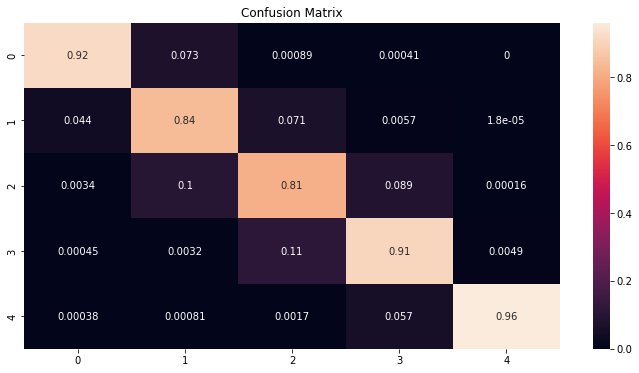

```python
 ##Build the random forest on the full training data
rf = RandomForestClassifier() # instance
rf.fit(x_train, y_train) # fit model
y_pred = rf.predict(x_test) # predict on test

# Calculate confusion matrix
con_mat = confusion_matrix(y_test, y_pred)
con_mat = con_mat / con_mat.astype(np.float).sum(axis=1)


print('Test Accuracy of random forest Model: ',round(100*rf.score(x_test, y_test),2),'%')
print('')
print('Train Accuracy of random forest Model: ',round(100*rf.score(x_train, y_train),2),'%')
print('')

# Evaluate model

print('Mean Squared Error (MSE): ',round(np.sqrt(mean_squared_error(y_test,y_pred)),4))


# Plot Model
plt.figure(figsize = (12,6))
ax = sns.heatmap(con_mat, annot = True)
plt.title("Confusion Matrix")
plt.show()

y_test_data = pd.DataFrame(y_test)
writer = pd.ExcelWriter("y-test-RF.xlsx", engine='xlsxwriter')
y_test_data.to_excel(writer,sheet_name = "sheet1_actual_data", index=False)
writer.save()

y_pred_data = pd.DataFrame(y_pred)
writer = pd.ExcelWriter("y_pred_RF.xlsx", engine='xlsxwriter')
y_pred_data.to_excel(writer,sheet_name = "sheet1_actual_data", index=False)
writer.save()
```

```python
from sklearn.tree import DecisionTreeRegressor
from sklearn.model_selection import train_test_split
reg=DecisionTreeRegressor()
reg.fit(x_train, y_train)
print('Test Accuracy of DecisionTree Regression: ',round(100*reg.score(x_test, y_test),2),'%')
print('')
print('Train Accuracy of DecisionTree Regression:',round(100*reg.score(x_train, y_train),2),'%')
print('')
y_pred=reg.predict(x_test)
print('Mean Squared Error (MSE): ',round(np.sqrt(mean_squared_error(y_test,y_pred)),4))


y_pred_data = pd.DataFrame(y_pred)
writer = pd.ExcelWriter("y_pred_DT.xlsx", engine='xlsxwriter')
y_pred_data.to_excel(writer,sheet_name = "sheet1_actual_data", index=False)
writer.save()
```

```
Test Accuracy of DecisionTree Regression:  90.52 %

Train Accuracy of DecisionTree Regression: 99.96 %

Mean Squared Error (MSE):  0.4136
```